# Assignment 2: Code for data modelling report

### Michael Teixeira S4133975

# Revolution Consulting Data Modeling Report

## 1. Setting the Research Goal

This section establishes the purpose and scope of our analysis, aligning it with Revolution Consulting's business needs.

### 1.1 Statement of Research Goal

How can Revolution Consulting improve consultant retention and attract top talent in order to maintain and enhance the quality of its consulting services?

### 1.2 Project Mission

In the context of Revolution Consulting's challenges with declining work quality and increased employee turnover, our mission is to:

1. Analyze employee data to uncover patterns related to attrition.
2. Segment employees into distinct groups based on their characteristics and risk of leaving.
3. Provide actionable insights and recommendations to improve employee retention and satisfaction.

This analysis will help Revolution Consulting address their concerns about losing valuable consultants and ultimately improve the quality of work delivered to clients.

### 1.3 Import Libraries and Dataset

```python
import pandas as pd
import numpy as np
from sklearn.cluster import KMeans, DBSCAN
from sklearn.preprocessing import MinMaxScaler, StandardScaler, LabelEncoder
from sklearn.neighbors import NearestNeighbors
from sklearn.metrics import silhouette_score
import matplotlib.pyplot as plt
import seaborn as sns

df = pd.read_csv('A2_HR_Employee_data.csv')
```

## 2. Exploratory Data Analysis

The dataset has been thoroughly cleaned and is now suitable for in-depth analysis.

```python
data = df.copy()

# Info
data.info()
```

```
<class 'pandas.core.frame.DataFrame'>
RangeIndex: 1470 entries, 0 to 1469
Data columns (total 22 columns):
 #   Column                    Non-Null Count  Dtype
---  ------                    --------------  -----
 0   EmployeeID                1470 non-null   int64
 1   Age                       1470 non-null   int64
 2   Resigned                  1470 non-null   object
 3   BusinessTravel            1470 non-null   object
 4   BusinessUnit              1470 non-null   object
 5   EducationLevel            1470 non-null   int64
 6   Gender                    1470 non-null   object
 7   JobSatisfaction           1470 non-null   int64
 8   MaritalStatus             1470 non-null   object
 9   MonthlyIncome             1470 non-null   int64
 10  NumCompaniesWorked        1470 non-null   int64
 11  OverTime                  1470 non-null   object
 12  PercentSalaryHike         1470 non-null   int64
 13  PerformanceRating         1470 non-null   int64
 14  AverageWeeklyHoursWorked  1470 non-null   float64
 15  TotalWorkingYears         1470 non-null   int64
 16  TrainingTimesLastYear     1470 non-null   int64
 17  WorkLifeBalance           1470 non-null   int64
 18  YearsAtCompany            1470 non-null   int64
 19  YearsInRole               1470 non-null   int64
 20  YearsSinceLastPromotion   1470 non-null   int64
 21  YearsWithCurrManager      1470 non-null   int64
dtypes: float64(1), int64(15), object(6)
memory usage: 252.8+ KB
```

```python
data.value_counts
```

[output not shown]

[output cut: 64 more lines]

### 2.1 Individual Column Analysis

We will run a function to visualize the distribution of variables and some of the statistics.

```python
# Function to visualize the distribution of variables
def create_grid(df, columns, num_rows=None, num_cols=None, bins=20):

  fig, axs = plt.subplots(num_rows, num_cols, figsize=(16, 12))

  for i, col in enumerate(columns):
    row, col_idx = i // num_cols, i % num_cols
    ax = axs[row, col_idx] if num_rows > 1 else axs[col_idx]

    def add_summary(summary_text, x_pos=0.95, y_pos=0.95, va='top', ha='right'):
      ax.text(x_pos, y_pos, summary_text, transform=ax.transAxes, fontsize=8,
               verticalalignment=va, horizontalalignment=ha, bbox=dict(facecolor='white', alpha=0.5))

    if df[col].dtype == 'object':
      # Categorical variables
      value_counts = df[col].value_counts()
      total = value_counts.sum()
      percentages = (value_counts / total * 100).round(1)

      sns.countplot(x=col, data=df, ax=ax)
      ax.set_title(f'Distribution of {col}')

      # Add percentage labels
      for i, v in enumerate(value_counts):
        ax.text(i, v, f'{percentages[i]}%', ha='center', va='bottom')

      # Add summary
      summary = f"Total: {total}\n" + "\n".join([f"{val}: {count} ({pct}%)" for val, count, pct in zip(value_counts.index, value_counts, percentages)])
      add_summary(summary)

    else:
      # Numerical variables
      sns.histplot(df[col], kde=True, bins=bins, ax=ax)
      ax.set_title(f'Distribution of {col}')

      # Add summary statistics
      mean = df[col].mean()
      median = df[col].median()
      std = df[col].std()

      stats_text = f"Mean: {mean:.2f}\nMedian: {median:.2f}\nStd Dev: {std:.2f}"
      add_summary(stats_text)


  plt.tight_layout()
  plt.show()


# Column lists
columns_categorical = ['Resigned', 'BusinessTravel', 'OverTime', 'MaritalStatus', 'Gender']
columns_numerical1 = ['JobSatisfaction', 'WorkLifeBalance', 'PerformanceRating', 'EducationLevel']
columns_numerical2 = ['YearsAtCompany', 'YearsInRole', 'MonthlyIncome', 'Age', 'NumCompaniesWorked',
                      'PercentSalaryHike', 'AverageWeeklyHoursWorked', 'YearsSinceLastPromotion',
                      'TrainingTimesLastYear', 'TotalWorkingYears', 'YearsWithCurrManager']
```

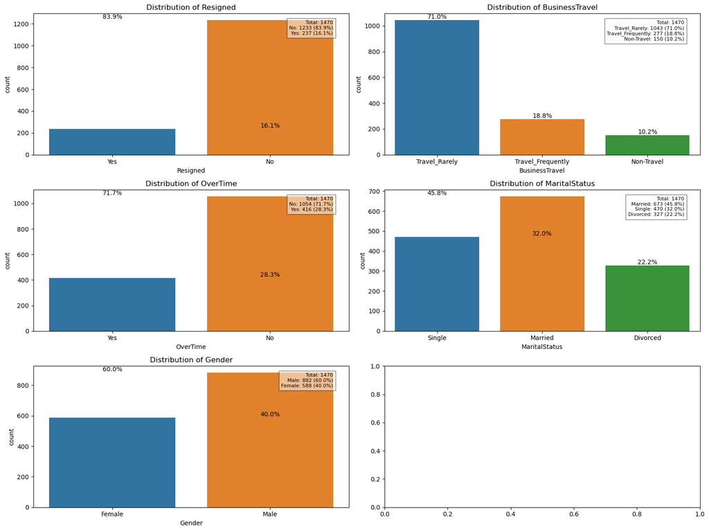

```python
# Show plots in grid
create_grid(data, columns_categorical, 3, 2)
```

##### Key Findings:

**Resigned:**  
16.1% of employees have resigned, which is a significant attrition rate. This directly relates to the company's concern about losing valuable consultants.

**OverTime:**  
28.3% of employees work overtime. This could be impacting work-life balance and potentially contributing to burnout and turnover.

**MaritalStatus:**  
Fairly diverse: 45.8% married, 32% single, 22.2% divorced. Different groups may have varying needs and challenges, which could affect retention strategies.

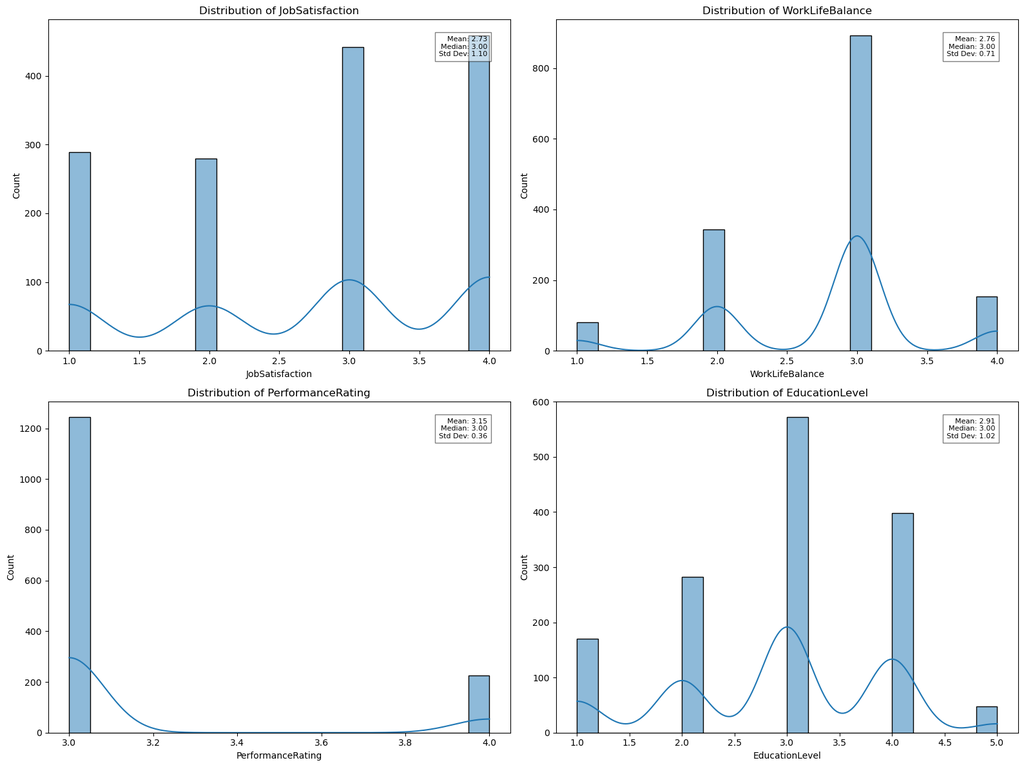

```python
# Show plots in grid
create_grid(data, columns_numerical1, 2, 2)
```

##### Key Findings:

**JobSatisfaction:**  
Fairly evenly distributed, with a slight lean towards higher satisfaction (3-4). This suggests room for improvement in employee satisfaction.

**WorkLifeBalance:**  
Most employees rate it as 3 out of 4, indicating generally good balance but potential for enhancement.

**PerformanceRating:**  
Heavily skewed towards 3 and 4, suggesting high performance overall. This contrasts with the reported declining work quality.

**EducationLevel:**  
Mostly levels 3-4, indicating a well-educated workforce.

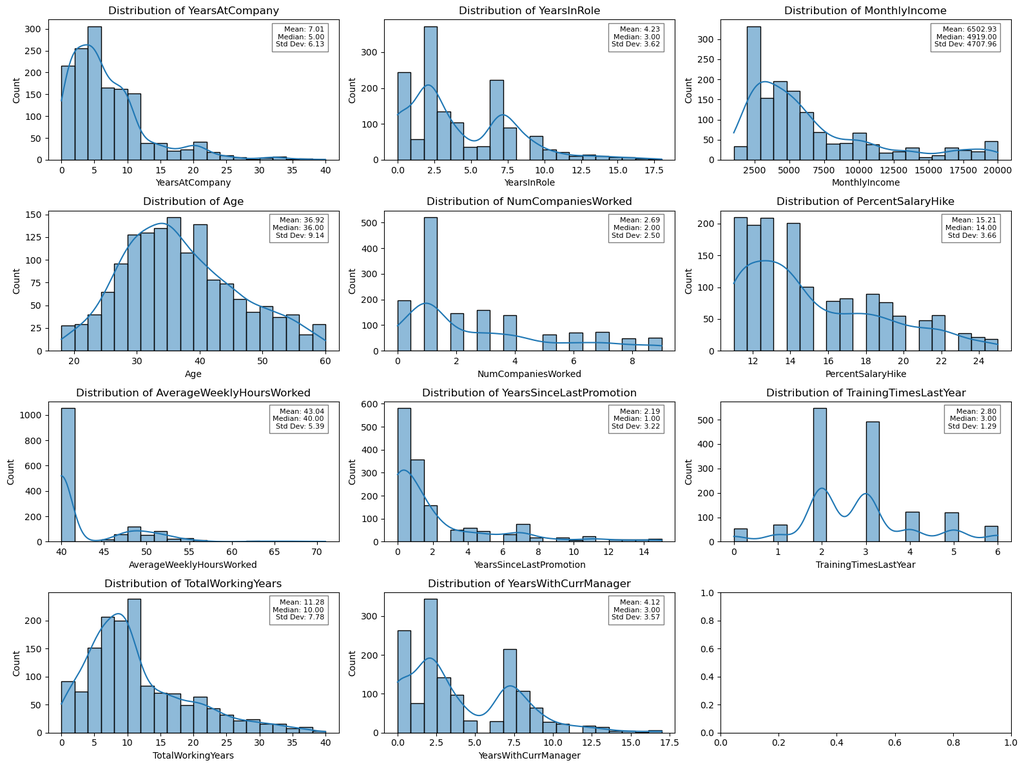

```python
# Show plots in grid
create_grid(data, columns_numerical2, 4, 3)
```

##### Key Findings:

**YearsAtCompany:**  
Right-skewed distribution: This indicates a larger proportion of employees with shorter tenures. This could be due to recent hiring, high turnover rates, or a company culture that doesn't prioritize long-term employee retention.

**YearsInRole:**  
Majority clustered in the 0-5 year range: This suggests frequent role changes or a lack of career progression opportunities. It might be worth investigating if this is related to company growth, employee dissatisfaction, or a lack of clear career paths.

**MonthlyIncome:**  
Right-skewed distribution with a wide range: This indicates a significant pay disparity within the company.

**Age:**  
Normal distribution centered around late 30s: This suggests a diverse workforce with a mix of experienced and younger employees.

**NumCompaniesWorked:**  
Most employees have worked for 1-3 companies: This indicates a relatively stable workforce with employees who have stayed with previous employers for a reasonable period.

**YearsSinceLastPromotion:**  
Highly right-skewed distribution: This suggests that a significant portion of employees haven't been promoted recently. This could be due to a lack of promotion opportunities, a stagnant company culture, or other factors.

**TrainingTimesLastYear:**  
Bimodal distribution: This might indicate that training is either mandatory or highly encouraged for certain groups of employees, leading to a concentration of training sessions in specific time periods.

**AverageWeeklyHoursWorked:**  
Right-skewed distribution: This suggests that a portion of employees are working significantly longer hours than others. It might be worth investigating if this is due to workload, overtime policies, or work-life balance issues.

**TotalWorkingYears:**  
Right-skewed distribution: This indicates a larger proportion of employees with fewer years of overall work experience. This could be due to recent hiring or a company culture that attracts younger employees.

**YearsWithCurrManager:**  
Right-skewed distribution: This suggests that many employees haven't been under their current manager for very long. This could be due to frequent managerial changes or a company culture that values frequent rotations.

### 2.2 Relationship Analysis

We will now, create a function to visualize the relationship of variables to each other, aiming to understand how various factors relate to employee resignation.

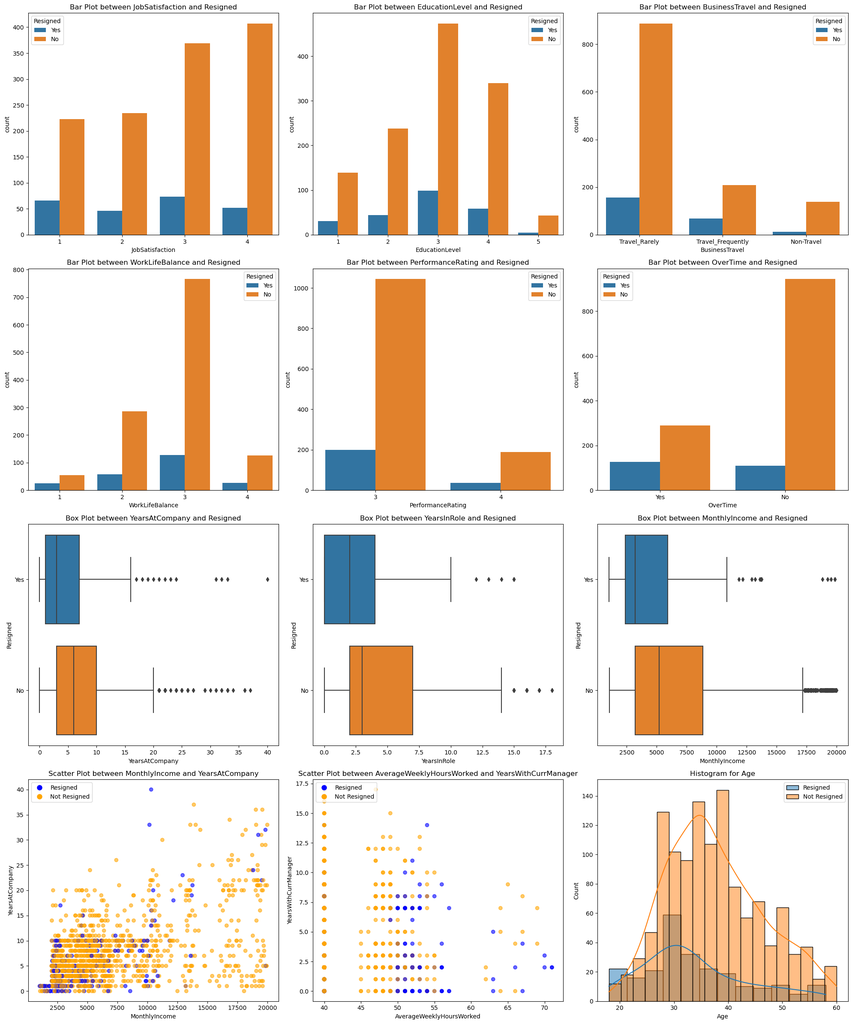

```python
# Visualization functions
def set_plot_title(ax, col1, col2=None, plot_type=None, title=None):
    if title:
        ax.set_title(title)
    elif col2:
        ax.set_title(f'{plot_type} between {col1} and {col2}')
    else:
        ax.set_title(f'{plot_type} for {col1}')

def plot_barplot(col1, col2, ax, data, title=None):
    sns.countplot(x=col1, hue=col2, data=data, ax=ax)
    set_plot_title(ax, col1, col2, 'Bar Plot', title)

def plot_boxplot(col1, col2, ax, data, title=None):
    sns.boxplot(x=col1, y=col2, data=data, ax=ax)
    set_plot_title(ax, col1, col2, 'Box Plot', title)

def plot_scatterplot(col1, col2, hue, ax, data, title=None):
    scatter = ax.scatter(data[col1], data[col2],
                         c=data[hue].map({'Yes': 'blue', 'No': 'orange'}),
                         alpha=0.6)
    ax.set_xlabel(col1)
    ax.set_ylabel(col2)
    set_plot_title(ax, col1, col2, 'Scatter Plot', title)

    # Create a custom legend
    legend_elements = [
        plt.Line2D([0], [0], marker='o', color='w', label='Resigned',
                   markerfacecolor='blue', markersize=10),
        plt.Line2D([0], [0], marker='o', color='w', label='Not Resigned',
                   markerfacecolor='orange', markersize=10)
    ]
    ax.legend(handles=legend_elements, loc='upper left')

def plot_histogram(col, hue, ax, data, title=None):
    sns.histplot(data[data[hue] == 'Yes'][col], label='Resigned', kde=True, ax=ax)
    sns.histplot(data[data[hue] == 'No'][col], label='Not Resigned', kde=True, ax=ax)
    ax.legend()
    set_plot_title(ax, col, plot_type='Histogram', title=title)

# Visualization runner
def create_visualizations(pairs_barplot, pairs_boxplot, pairs_scatterplot, pairs_histogram, data):
    fig, axs = plt.subplots(4, 3, figsize=(20, 24))

    # Plot bar plots
    for i, (col1, col2) in enumerate(pairs_barplot):
        row, col_idx = divmod(i, 3)
        plot_barplot(col1, col2, axs[row, col_idx], data)

    # Plot box plots
    for i, (col1, col2) in enumerate(pairs_boxplot):
        row, col_idx = divmod(i + len(pairs_barplot), 3)
        plot_boxplot(col1, col2, axs[row, col_idx], data)

    # Plot scatter plot
    for i, (col1, col2, hue) in enumerate(pairs_scatterplot):
        row, col_idx = divmod(i + len(pairs_barplot) + len(pairs_boxplot), 3)
        plot_scatterplot(col1, col2, hue, axs[row, col_idx], data)

    # Plot histogram
    for i, (col, hue) in enumerate(pairs_histogram):
        row, col_idx = divmod(i + len(pairs_barplot) + len(pairs_boxplot) + len(pairs_scatterplot), 3)
        plot_histogram(col, hue, axs[row, col_idx], data)


    plt.tight_layout()
    plt.show()

# Define pairs of columns to analyze
pairs_barplot = [
    ('JobSatisfaction', 'Resigned'),
    ('EducationLevel', 'Resigned'),
    ('BusinessTravel', 'Resigned'),
    ('WorkLifeBalance', 'Resigned'),
    ('PerformanceRating', 'Resigned'),
    ('OverTime', 'Resigned')
]

pairs_boxplot = [
    ('YearsAtCompany', 'Resigned'),
    ('YearsInRole', 'Resigned'),
    ('MonthlyIncome', 'Resigned')
]

pairs_scatterplot = [
    ('MonthlyIncome', 'YearsAtCompany', 'Resigned'),
    ('AverageWeeklyHoursWorked', 'YearsWithCurrManager', 'Resigned'),
]

pairs_histogram = [
    ('Age', 'Resigned')
]

# Create visualisations
create_visualizations(pairs_barplot, pairs_boxplot, pairs_scatterplot, pairs_histogram, data)
```

##### Key Findings:

**Job Satisfaction and Resignation:**  
While there's a slight tendency for employees with lower job satisfaction to resign, the relationship is not entirely conclusive. Other factors may also play a significant role.

**Business Travel and Resignation:**  
Frequent business travelers seem to have a slightly higher propensity to resign. This could be attributed to factors such as work-life balance issues, frequent absences, or the demanding nature of travel.

**Work-Life Balance and Resignation:**  
Employees with poor work-life balance are more likely to resign, emphasizing the importance of creating a healthy work environment.

**Performance Rating and Resignation:**  
While the relationship is not entirely clear, there might be a slight tendency for employees with lower performance ratings to resign. However, other factors like job satisfaction or opportunities could also influence turnover.

**Years at Company and Resignation:**  
Employees with longer tenures might be less likely to resign, suggesting that loyalty and organizational commitment increase with time.

**Monthly Income, YearsAtCompany and Resignation:**  
While the scatter plot reveals general trends, individual variations exist. Some employees with high incomes may stay with the company for many years, while others with lower incomes may resign early.

**Age and Resignation:**  
The chart reveals a noticeable peak in resignations among employees in their late 20s to early 30s. Also shows that the proportion of people that resign in their early 20's is significantly higher that who does not. This suggests that this age group is more likely to leave the organization compared to other age brackets.

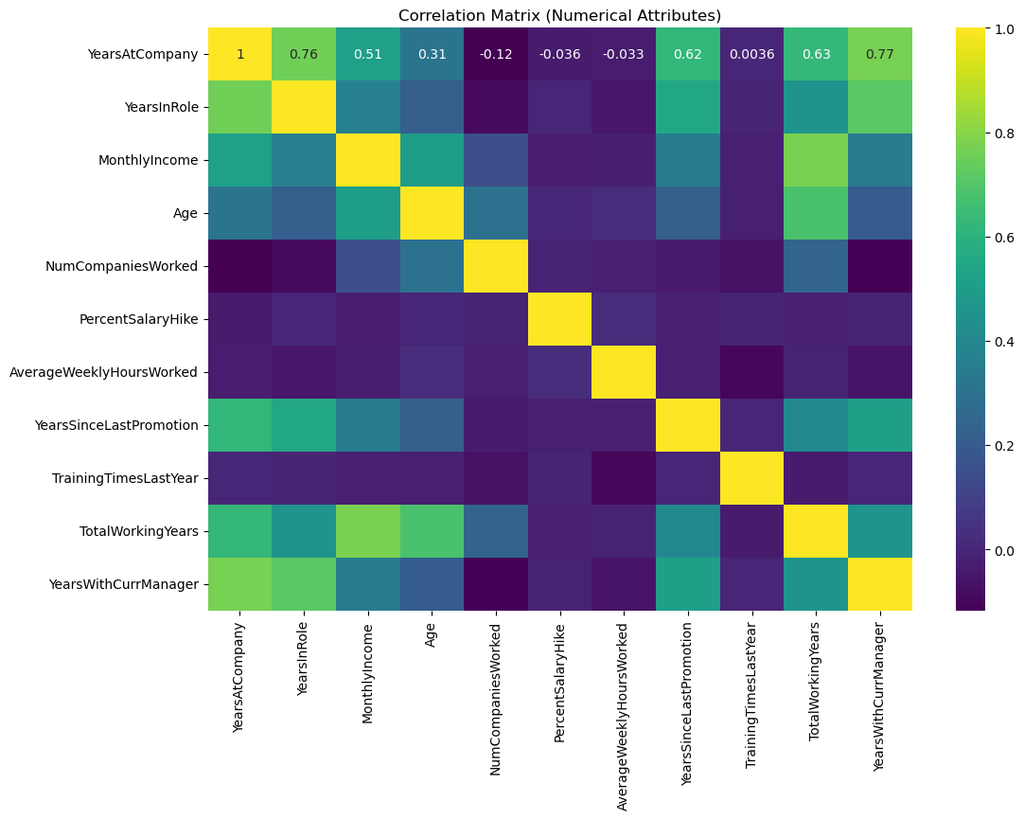

```python
# Calculate correlation matrix for numerical columns 2
corr_matrix = data[columns_numerical2].corr()

# Create a heatmap
plt.figure(figsize=(12, 8))
sns.heatmap(corr_matrix, annot=True, cmap='viridis')
plt.title('Correlation Matrix (Numerical Attributes)')
plt.show()
```

##### Key Findings:

**Strong Positive Correlations:**

As anticipated, the following variables exhibit a strong positive correlation:

[output not shown]

These findings align with our expectations, suggesting that employees who have been with the company longer as consequence have greater tenure in their current roles and more overall work experience.

**Moderate Positive Correlations:**

[output not shown]

**Moderate Negative Correlations:**

[output not shown]

**Weak Correlations:**

[output not shown]

## 3. Data Modeling

To create effective clustering models using k-means and DBSCAN for analyzing employee attrition, we should focus on variables that are most likely to influence an employee's decision to stay or leave. We will pre process the data by ensure all variables are properly scaled, and the categorical ones labeled.

KMeans is a method that groups data into a set number of clusters. It works by putting similar data points together based on how close they are to each other. We'll create a graph called the "elbow method" to help us figure out how many clusters we should use.

DBSCAN is another way to group data, but it looks for areas where there are lots of data points close together. It doesn't need you to decide how many groups to make beforehand. We'll use something called a "K-Distance Graph" to help set up DBSCAN correctly.

##### 3.1 Data Preparation:

```python
# Define relevant variables as specified
relevant_variables = [
    'Age', 'MonthlyIncome', 'JobSatisfaction', 'EducationLevel',
    'WorkLifeBalance', 'YearsAtCompany', 'YearsSinceLastPromotion',
    'PercentSalaryHike', 'AverageWeeklyHoursWorked', 'TotalWorkingYears',
    'YearsInRole', 'YearsWithCurrManager'
]
# Create a new column to indicate resignation an gender as binary (1 for Yes or Male, 0 for No or Female)
data['Resigned'] = data['Resigned'].apply(lambda x: 1 if x == 'Yes' else 0)


# All numerical variables besides EmployeeID
numerical_columns = columns_numerical1 + columns_numerical2

# Normalize all numerical data using Min-Max scaling
scaler = MinMaxScaler()
data_scaled_all = pd.DataFrame(scaler.fit_transform(data[numerical_columns]), columns=numerical_columns)

# Encode categorical variables in the relevant_variables list
categorical_variables = [var for var in relevant_variables if var not in numerical_columns]
label_encoder = LabelEncoder()

for column in categorical_variables:
    if column in data.columns:
        data[column] = label_encoder.fit_transform(data[column])
        data_scaled_all[column] = data[column]  # Add encoded categorical variables to scaled data
```

##### 3.2 Selecting k and find the right value for Eps

Now we can plot the WCSS values for every k and plot the k-distance graph.

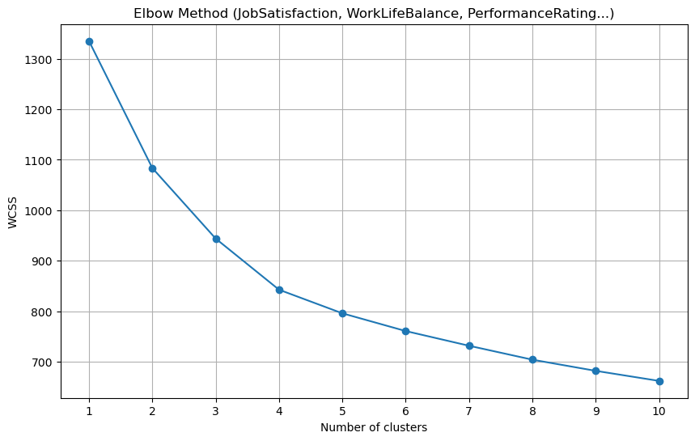

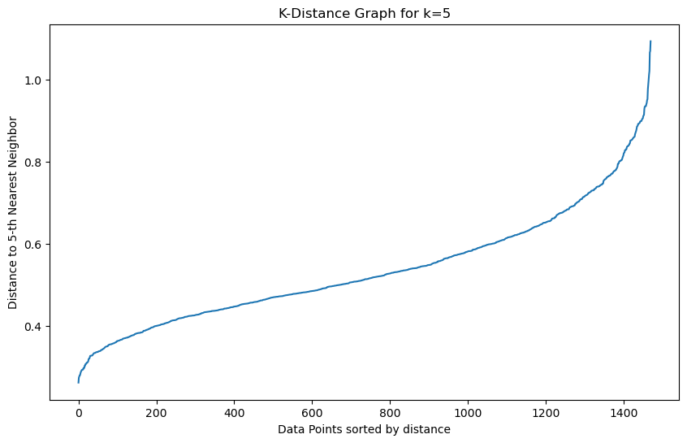

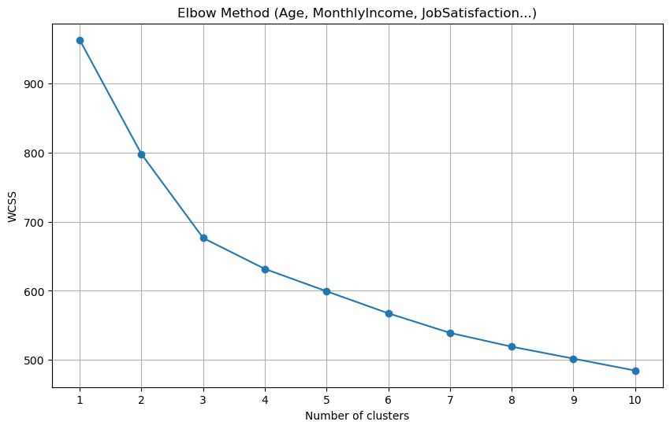

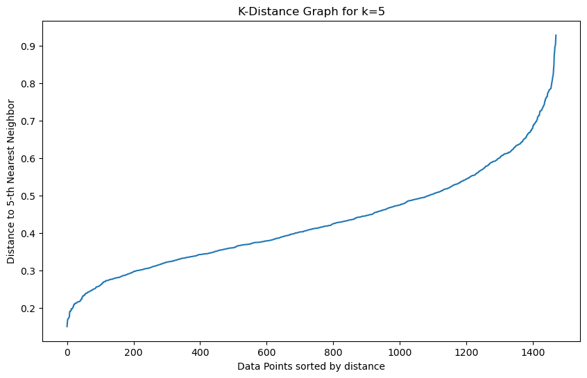

```python
def plot_k_distance_graph(data, k):
    nearest_neighbors = NearestNeighbors(n_neighbors=k)
    neighbors = nearest_neighbors.fit(data)
    distances, indices = neighbors.kneighbors(data)
    distances = np.sort(distances[:, k-1])

    plt.figure(figsize=(10, 6))
    plt.plot(distances)
    plt.title(f'K-Distance Graph for k={k}')
    plt.xlabel('Data Points sorted by distance')
    plt.ylabel(f'Distance to {k}-th Nearest Neighbor')
    plt.show()

def perform_clustering(data, variables, max_clusters=10):
    data_to_cluster = data[variables]

    # KMeans Elbow method
    wcss = []
    for i in range(1, max_clusters + 1):
        kmeans = KMeans(n_clusters=i, init='k-means++', max_iter=300, n_init=10, random_state=0)
        kmeans.fit(data_to_cluster)
        wcss.append(kmeans.inertia_)

    # Plot elbow curve
    plt.figure(figsize=(10, 6))
    plt.plot(range(1, max_clusters + 1), wcss, marker='o')
    plt.title(f'Elbow Method ({", ".join(variables[:3])}...)')
    plt.xlabel('Number of clusters')
    plt.ylabel('WCSS')
    plt.xticks(range(1, max_clusters + 1))
    plt.grid(True)
    plt.show()

    # Choose optimal number of clusters
    optimal_clusters = 4  # Modify this based on elbow curve observation

    # Perform KMeans clustering
    kmeans = KMeans(n_clusters=optimal_clusters, init='k-means++', max_iter=300, n_init=10, random_state=0)
    kmeans_labels = kmeans.fit_predict(data_to_cluster)

    # DBSCAN
    # Plot k-distance graph to help choose eps
    plot_k_distance_graph(data_to_cluster, k=5)


    # Perform DBSCAN clustering
    dbscan = DBSCAN(eps=0.6, min_samples=5)  # Modify this based on elbow curve observation
    dbscan_labels = dbscan.fit_predict(data_to_cluster)

    return kmeans_labels, dbscan_labels, optimal_clusters


# Perform clustering for all numerical variables
all_num_kmeans_labels, all_num_dbscan_labels, all_num_clusters = perform_clustering(data_scaled_all, numerical_columns)

# Perform clustering for relevant variables
relevant_kmeans_labels, relevant_dbscan_labels, relevant_clusters = perform_clustering(data_scaled_all, relevant_variables)
```

##### 3..2.2 Intrinsic evaluation: The silhouette method

We will now consider a good value for k using the silhouette method.

```
For n_clusters = 2, the average silhouette score is : 0.2937
```

```
For n_clusters = 3, the average silhouette score is : 0.1856
```

```
For n_clusters = 4, the average silhouette score is : 0.1639
```

```
For n_clusters = 5, the average silhouette score is : 0.1522
```

```
For n_clusters = 6, the average silhouette score is : 0.1339
```

```
For n_clusters = 7, the average silhouette score is : 0.1432
```

```
For n_clusters = 8, the average silhouette score is : 0.1241
```

```
For n_clusters = 9, the average silhouette score is : 0.1232
```

```
For n_clusters = 10, the average silhouette score is : 0.1231
```

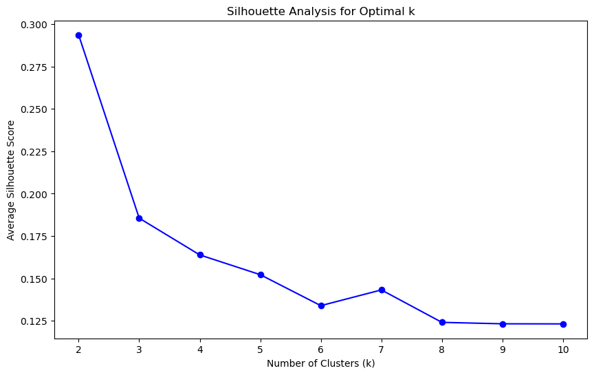

```
The optimal number of clusters based on the silhouette method is: 2
```

```
For n_clusters = 2, the average silhouette score is : 0.1945
```

```
For n_clusters = 3, the average silhouette score is : 0.1762
```

```
For n_clusters = 4, the average silhouette score is : 0.1506
```

```
For n_clusters = 5, the average silhouette score is : 0.1561
```

```
For n_clusters = 6, the average silhouette score is : 0.1283
```

```
For n_clusters = 7, the average silhouette score is : 0.1317
```

```
For n_clusters = 8, the average silhouette score is : 0.1252
```

```
For n_clusters = 9, the average silhouette score is : 0.1247
```

```
For n_clusters = 10, the average silhouette score is : 0.1247
```

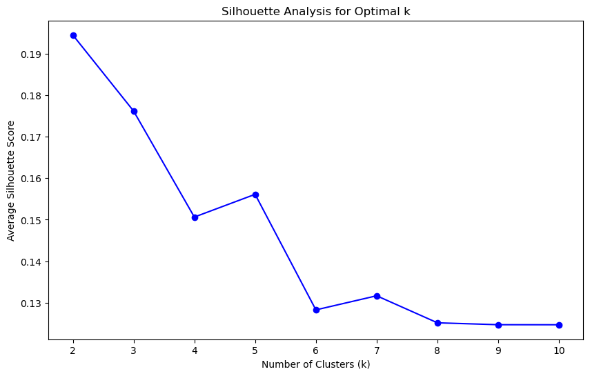

```
The optimal number of clusters based on the silhouette method is: 2
```

```python
def find_optimal_k(data, max_k):
    silhouette_scores = []
    k_values = range(2, max_k + 1)  # Start from 2 clusters

    for k in k_values:
        kmeans = KMeans(n_clusters=k, random_state=42)
        cluster_labels = kmeans.fit_predict(data)
        silhouette_avg = silhouette_score(data, cluster_labels)
        silhouette_scores.append(silhouette_avg)
        print(f"For n_clusters = {k}, the average silhouette score is : {silhouette_avg:.4f}")

    # Plot silhouette scores
    plt.figure(figsize=(10, 6))
    plt.plot(k_values, silhouette_scores, 'bo-')
    plt.xlabel('Number of Clusters (k)')
    plt.ylabel('Average Silhouette Score')
    plt.title('Silhouette Analysis for Optimal k')
    plt.show()

    # Find the best k
    optimal_k = k_values[np.argmax(silhouette_scores)]
    print(f"\nThe optimal number of clusters based on the silhouette method is: {optimal_k}")

    return optimal_k

# Usage example:
optimal_k = find_optimal_k(data_scaled_all[numerical_columns], max_k=10)
optimal_k_relevant = find_optimal_k(data_scaled_all[relevant_variables], max_k=10)
```

##### 3.3 Visualisation of clusters and summaries

We can now analyze how the clusters are distributed, compare the data summaries for the overall dataset versus data filtered for Consultants only, and examine the resignation rate within each cluster.

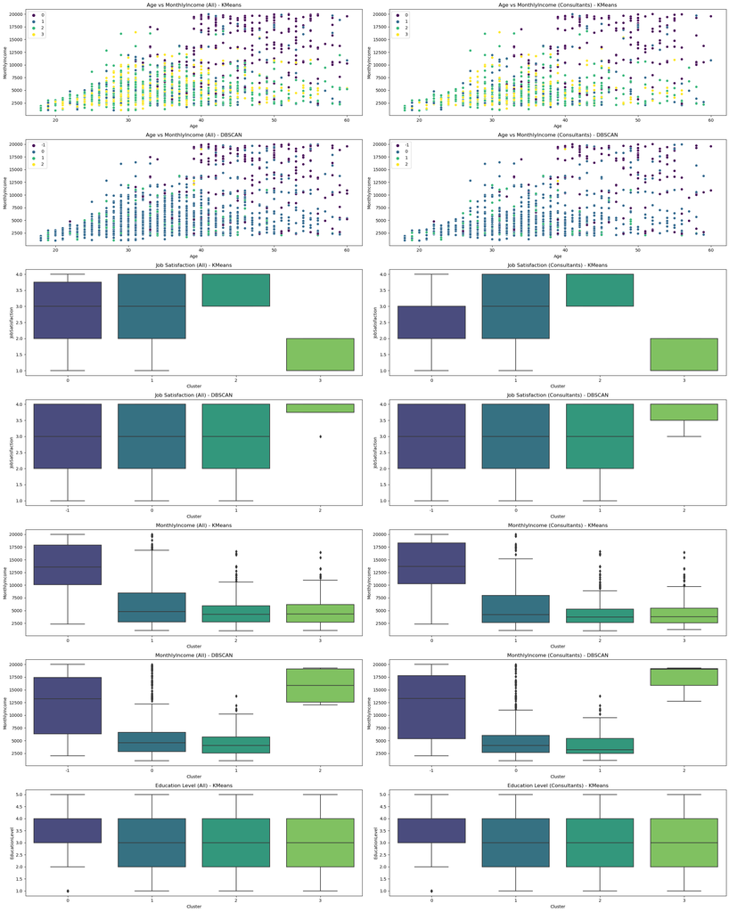

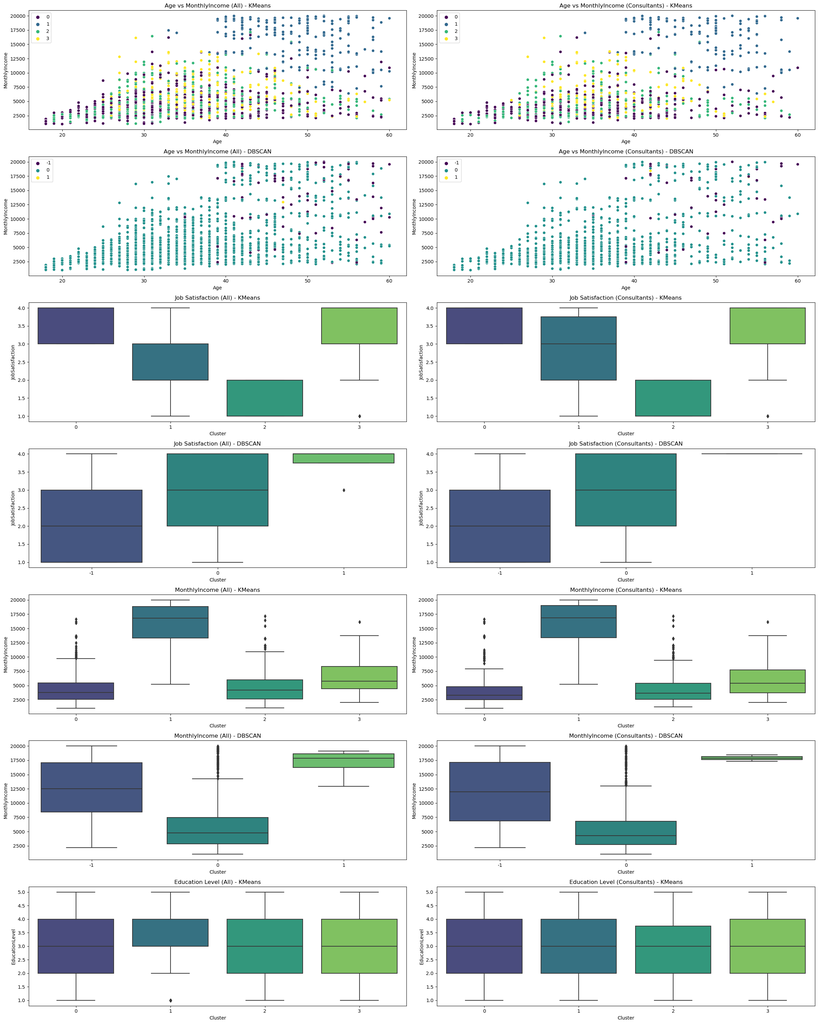

```
Cluster Summaries (KMeans - All Numerical - All Data):
         JobSatisfaction  WorkLifeBalance  PerformanceRating  EducationLevel  \
Cluster
0               2.697674         2.775194                3.0        3.069767
1               2.734513         2.765487                4.0        2.853982
2               3.516393         2.768852                3.0        2.890164
3               1.468085         2.736702                3.0        2.877660

         YearsAtCompany  YearsInRole  MonthlyIncome        Age  \
Cluster
0             14.546512     7.519380   13234.918605  45.616279
1              7.057522     4.526549    6313.893805  36.964602
2              5.042623     3.286885    4737.724590  34.827869
3              4.994681     3.321809    4861.031915  34.335106

         NumCompaniesWorked  PercentSalaryHike  AverageWeeklyHoursWorked  \
Cluster
0                  3.174419          13.600775                 42.899225
1                  2.610619          21.849558                 43.411504
2                  2.508197          14.180328                 43.290164
3                  2.712766          13.992021                 42.515957

         YearsSinceLastPromotion  TrainingTimesLastYear  TotalWorkingYears  \
Cluster
0                       5.337209               2.786822          22.693798
1                       2.323009               2.752212          11.402655
2                       1.321311               2.793443           8.131148
3                       1.351064               2.845745           8.481383

         YearsWithCurrManager
Cluster
0                    7.360465
1                    4.314159
2                    3.198361
3                    3.287234

Resignation Rates per Cluster (KMeans - All Numerical - All Data):
Cluster
0    0.089147
1    0.163717
```

[output cut: 290 more lines]

```
-1    0.176471
 0    0.136564
 1    0.000000
Name: Resigned, dtype: float64

Cluster with highest resignation rate: -1
Highest resignation rate: 17.65%

Gender Distribution per Cluster (KMeans - All Numerical - All Data):
Gender     Female      Male
Cluster
0        0.434109  0.565891
1        0.415929  0.584071
2        0.377049  0.622951
3        0.404255  0.595745
```

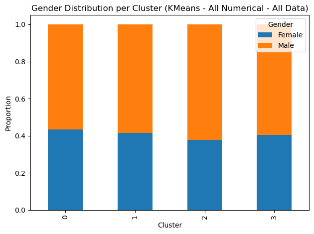

```
Gender Distribution per Cluster (KMeans - All Numerical - Consultants):
Gender     Female      Male
Cluster
0        0.417647  0.582353
1        0.391026  0.608974
2        0.357500  0.642500
3        0.442553  0.557447
```

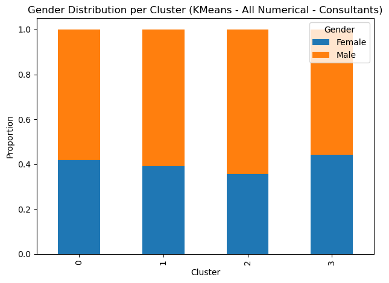

```
Gender Distribution per Cluster (DBSCAN - All Numerical - All Data):
Gender     Female      Male
Cluster
-1       0.425000  0.575000
 0       0.392157  0.607843
 1       0.406452  0.593548
 2       0.750000  0.250000
```

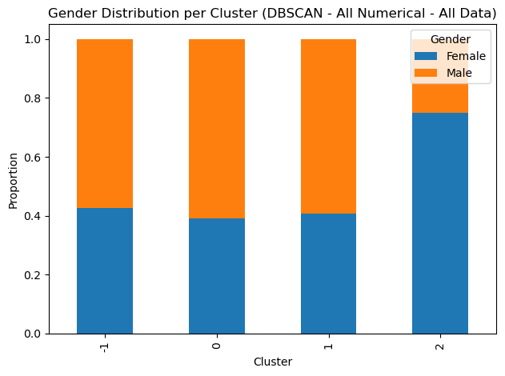

```
Gender Distribution per Cluster (DBSCAN - All Numerical - Consultants):
Gender     Female      Male
Cluster
-1       0.412121  0.587879
 0       0.391241  0.608759
 1       0.379630  0.620370
 2       0.666667  0.333333
```

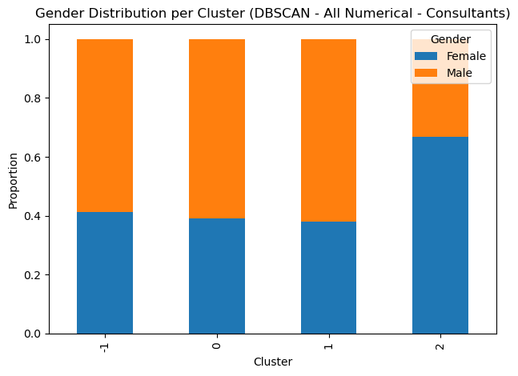

```
Gender Distribution per Cluster (KMeans - Relevant Variables - All Data):
Gender     Female      Male
Cluster
0        0.376181  0.623819
1        0.440191  0.559809
2        0.404977  0.595023
3        0.406897  0.593103
```

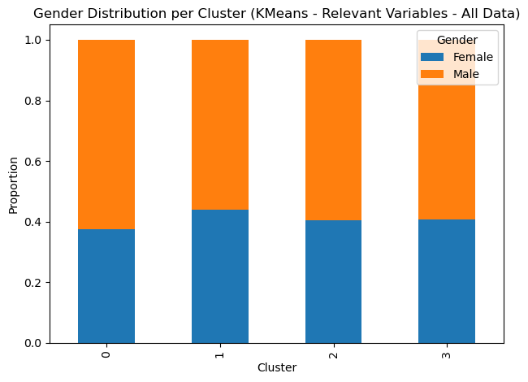

```
Gender Distribution per Cluster (KMeans - Relevant Variables - Consultants):
Gender     Female      Male
Cluster
0        0.332394  0.667606
1        0.415493  0.584507
2        0.430070  0.569930
3        0.443820  0.556180
```

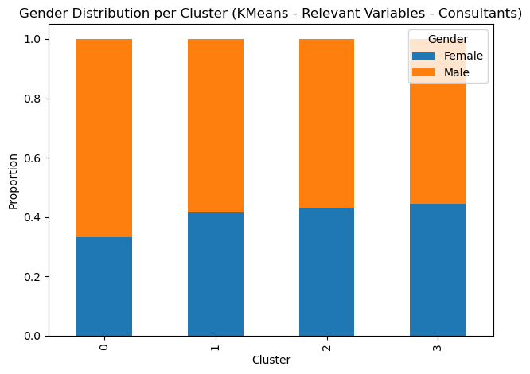

```
Gender Distribution per Cluster (DBSCAN - Relevant Variables - All Data):
Gender     Female      Male
Cluster
-1       0.426829  0.573171
 0       0.398844  0.601156
 1       0.250000  0.750000
```

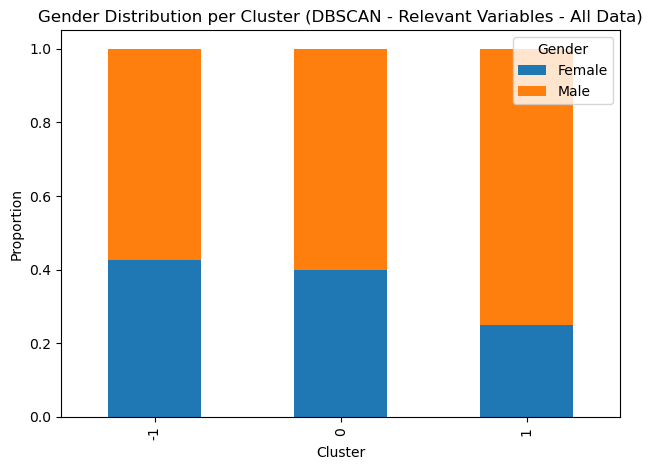

```
Gender Distribution per Cluster (DBSCAN - Relevant Variables - Consultants):
Gender     Female      Male
Cluster
-1       0.411765  0.588235
 0       0.393172  0.606828
 1       0.500000  0.500000
```

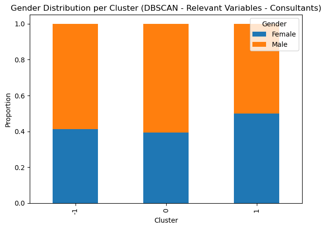

```python
def filter_consultants(data):
    return data[data['BusinessUnit'] == 'Consultants']

def visualize_clusters_comparison(data, kmeans_label, dbscan_label):
    consultants_data = filter_consultants(data)
    consultants_mask = data['BusinessUnit'] == 'Consultants'
    consultants_kmeans_label = kmeans_label[consultants_mask]
    consultants_dbscan_label = dbscan_label[consultants_mask]

    plt.figure(figsize=(24, 30))

def create_scatter(ax, x, y, hue, data, title):
        sns.scatterplot(ax=ax, x=x, y=y, hue=hue, data=data, palette='viridis')
        ax.set_title(title)
        ax.set_xlabel(x)
        ax.set_ylabel(y)

def create_boxplot(ax, x, y, data, title):
        sns.boxplot(ax=ax, x=x, y=y, data=data, palette='viridis')
        ax.set_title(title)
        ax.set_xlabel('Cluster')
        ax.set_ylabel(y)

def visualize_clusters_comparison(data, kmeans_label, dbscan_label):

    consultants_data = filter_consultants(data)
    consultants_mask = data['BusinessUnit'] == 'Consultants'
    consultants_kmeans_label = kmeans_label[consultants_mask]
    consultants_dbscan_label = dbscan_label[consultants_mask]

    plt.figure(figsize=(24, 30))  # Adjust figure size as needed

    # Create subplots in one go
    fig, axes = plt.subplots(7, 2, figsize=(24, 30))  # Creates a 6x2 grid of subplots

    # Age vs MonthlyIncome by KMeans
    create_scatter(axes[0, 0], 'Age', 'MonthlyIncome', kmeans_label, data, 'Age vs MonthlyIncome (All) - KMeans')
    create_scatter(axes[0, 1], 'Age', 'MonthlyIncome', consultants_kmeans_label, consultants_data, 'Age vs MonthlyIncome (Consultants) - KMeans')

    # Age vs MonthlyIncome by DBSCAN
    create_scatter(axes[1, 0], 'Age', 'MonthlyIncome', dbscan_label, data, 'Age vs MonthlyIncome (All) - DBSCAN')
    create_scatter(axes[1, 1], 'Age', 'MonthlyIncome', consultants_dbscan_label, consultants_data, 'Age vs MonthlyIncome (Consultants) - DBSCAN')

    # Job Satisfaction by KMeans Clusters
    create_boxplot(axes[2, 0], kmeans_label, 'JobSatisfaction', data, 'Job Satisfaction (All) - KMeans')
    create_boxplot(axes[2, 1], consultants_kmeans_label, 'JobSatisfaction', consultants_data, 'Job Satisfaction (Consultants) - KMeans')

    # Job Satisfaction by DBSCAN Clusters
    create_boxplot(axes[3, 0], dbscan_label, 'JobSatisfaction', data, 'Job Satisfaction (All) - DBSCAN')
    create_boxplot(axes[3, 1], consultants_dbscan_label, 'JobSatisfaction', consultants_data, 'Job Satisfaction (Consultants) - DBSCAN')

    # Monthly Income by KMeans Clusters
    create_boxplot(axes[4, 0], kmeans_label, 'MonthlyIncome', data, 'MonthlyIncome (All) - KMeans')
    create_boxplot(axes[4, 1], consultants_kmeans_label, 'MonthlyIncome', consultants_data, 'MonthlyIncome (Consultants) - KMeans')

    # Monthly Income by DBSCAN Clusters
    create_boxplot(axes[5, 0], dbscan_label, 'MonthlyIncome', data, 'MonthlyIncome (All) - DBSCAN')
    create_boxplot(axes[5, 1], consultants_dbscan_label, 'MonthlyIncome', consultants_data, 'MonthlyIncome (Consultants) - DBSCAN')

    # Education Level by KMeans Clusters
    create_boxplot(axes[6, 0], kmeans_label, 'EducationLevel', data, 'Education Level (All) - KMeans')
    create_boxplot(axes[6, 1], consultants_kmeans_label, 'EducationLevel', consultants_data, 'Education Level (Consultants) - KMeans')


    plt.tight_layout()
    plt.show()

def analyze_clusters_comparison(data, cluster_labels, variables, method_name):
    def analyze_group(group_data, group_labels, group_name):
        group_data_with_clusters = group_data.copy()
        group_data_with_clusters['Cluster'] = group_labels

        cluster_summary = group_data_with_clusters.groupby('Cluster')[variables].mean()
        print(f"\nCluster Summaries ({method_name} - {group_name}):")
        print(cluster_summary)

        resignation_rate = group_data_with_clusters.groupby('Cluster')['Resigned'].mean()
        print(f"\nResignation Rates per Cluster ({method_name} - {group_name}):")
        print(resignation_rate)

        highest_resignation_cluster = resignation_rate.idxmax()
        highest_resignation_rate = resignation_rate.max()
        print(f'\nCluster with highest resignation rate: {highest_resignation_cluster}')
        print(f'Highest resignation rate: {highest_resignation_rate:.2%}')

    analyze_group(data, cluster_labels, "All Data")
    consultants_data = filter_consultants(data)
    consultants_mask = data['BusinessUnit'] == 'Consultants'
    consultants_labels = cluster_labels[consultants_mask]
    analyze_group(consultants_data, consultants_labels, "Consultants")

def analyze_gender_distribution_comparison(data, cluster_labels, method_name):
    def analyze_group(group_data, group_labels, group_name):
        group_data_with_clusters = group_data.copy()
        group_data_with_clusters['Cluster'] = group_labels

        gender_distribution = group_data_with_clusters.groupby('Cluster')['Gender'].value_counts(normalize=True).unstack()
        gender_distribution = gender_distribution.fillna(0)  # Replace NaN with 0

        print(f"\nGender Distribution per Cluster ({method_name} - {group_name}):")
        print(gender_distribution)

        plt.figure(figsize=(12, 6))
        gender_distribution.plot(kind='bar', stacked=True)
        plt.title(f'Gender Distribution per Cluster ({method_name} - {group_name})')
        plt.xlabel('Cluster')
        plt.ylabel('Proportion')
        plt.legend(title='Gender')
        plt.tight_layout()
        plt.show()

    analyze_group(data, cluster_labels, "All Data")
    consultants_data = filter_consultants(data)
    consultants_mask = data['BusinessUnit'] == 'Consultants'
    consultants_labels = cluster_labels[consultants_mask]
    analyze_group(consultants_data, consultants_labels, "Consultants")

# Main execution
if __name__ == "__main__":
    # Visualize clusters
    visualize_clusters_comparison(data, all_num_kmeans_labels, all_num_dbscan_labels)
    visualize_clusters_comparison(data, relevant_kmeans_labels, relevant_dbscan_labels)

    # Analyze clusters
    analyze_clusters_comparison(data, all_num_kmeans_labels, numerical_columns, 'KMeans - All Numerical')
    analyze_clusters_comparison(data, all_num_dbscan_labels, numerical_columns, 'DBSCAN - All Numerical')
    analyze_clusters_comparison(data, relevant_kmeans_labels, relevant_variables, 'KMeans - Relevant Variables')
    analyze_clusters_comparison(data, relevant_dbscan_labels, relevant_variables, 'DBSCAN - Relevant Variables')

    # Analyze gender distribution
    analyze_gender_distribution_comparison(data, all_num_kmeans_labels, 'KMeans - All Numerical')
    analyze_gender_distribution_comparison(data, all_num_dbscan_labels, 'DBSCAN - All Numerical')
    analyze_gender_distribution_comparison(data, relevant_kmeans_labels, 'KMeans - Relevant Variables')
    analyze_gender_distribution_comparison(data, relevant_dbscan_labels, 'DBSCAN - Relevant Variables')
```

### 3.4 Model Evaluation

Model evaluation using 'silhouette_score':

```python
def evaluate_clustering(data, kmeans_labels, dbscan_labels, variables, title):
    # Calculate silhouette scores
    kmeans_silhouette = silhouette_score(data[variables], kmeans_labels)

    # For DBSCAN, we need to exclude noise points (labeled as -1)
    dbscan_points = data[variables][dbscan_labels != -1]
    dbscan_labels_filtered = dbscan_labels[dbscan_labels != -1]
    dbscan_silhouette = silhouette_score(dbscan_points, dbscan_labels_filtered) if len(np.unique(dbscan_labels_filtered)) > 1 else 0

    print(f"\nSilhouette Analysis for {title}")
    print(f"Silhouette Score for KMeans: {kmeans_silhouette:.4f}")
    print(f"Silhouette Score for DBSCAN: {dbscan_silhouette:.4f}")


# Evaluate clustering for all numerical variables
evaluate_clustering(data_scaled_all, all_num_kmeans_labels, all_num_dbscan_labels, numerical_columns, "All Numerical Variables")

# Evaluate clustering for relevant variables
evaluate_clustering(data_scaled_all, relevant_kmeans_labels, relevant_dbscan_labels, relevant_variables, "Relevant Variables")
```

```
Silhouette Analysis for All Numerical Variables
Silhouette Score for KMeans: 0.1639
Silhouette Score for DBSCAN: 0.2335

Silhouette Analysis for Relevant Variables
Silhouette Score for KMeans: 0.1537
Silhouette Score for DBSCAN: 0.2793
```

Despite DBSCAN's superior performance in the Silhouette Analysis, it was more challenging to verify and interpret these results through the selected clusters.